# Modelling Draft 2 - Year Processing Ver - dfN1

```python
import os
os.getcwd()
```

```
'C:\\Users\\zwu26\\Desktop'
```

```python
# Import dataset

import numpy as np
import pandas as pd
import matplotlib.pyplot as plt
import seaborn as sns

# %matplotlib inline

# from google.colab import drive
# drive.mount('/content/gdrive')
# path='/content/gdrive/My Drive/Colab/Universe Data/'
```

```python
path = 'C:/Users/zwu26/Desktop/Universe Data/'
```

```python
dfN1 = pd.read_csv (path+'dfN1.csv') #, low_memory=False)
dfN1.head()
```

|  | Patient MRN | Encounter Date | CombinedIndicator | SixMonthIntervalsBeforeDiagnosis | Component Common Name | Result Text Value | tMN_Patient | Birth Date | Married | Female | Age_at_Encounter |
| --- | --- | --- | --- | --- | --- | --- | --- | --- | --- | --- | --- |
| 0 | 42190 | 2022-09-14 00:00:00 | MCV -1 | -1 | MCV | 91.00 | 0 | 1950-10-31 | 0 | 1 | 71.871321 |
| 1 | 42190 | 2022-09-14 00:00:00 | RBC -1 | -1 | RBC | 3.78 | 0 | 1950-10-31 | 0 | 1 | 71.871321 |
| 2 | 42190 | 2022-09-14 00:00:00 | RDW-CV -1 | -1 | RDW-CV | 14.90 | 0 | 1950-10-31 | 0 | 1 | 71.871321 |
| 3 | 42190 | 2022-09-14 00:00:00 | RDW-SD -1 | -1 | RDW-SD | 48.50 | 0 | 1950-10-31 | 0 | 1 | 71.871321 |
| 4 | 42190 | 2022-09-14 00:00:00 | WBC -1 | -1 | WBC | 3.70 | 0 | 1950-10-31 | 0 | 1 | 71.871321 |

```python
#importing Classifier Modules

from sklearn.linear_model import LogisticRegression
from sklearn.svm import SVC, LinearSVC
from sklearn.neighbors import KNeighborsClassifier
from sklearn.tree import DecisionTreeClassifier
from sklearn.ensemble import RandomForestClassifier
from sklearn.naive_bayes import GaussianNB
from sklearn.linear_model import Perceptron
from sklearn.linear_model import SGDClassifier
```

```python
# ! pip install data_describe
```

```python
import data_describe as dd
```

#### Identify correllation

Visualize correlation via a heatmap

```python
# Pivot the DataFrame using pivot_table and handle duplicates with mean aggregation
pivot_dfN1 = pd.pivot_table(dfN1, values='Result Text Value', index=['Patient MRN', 'Encounter Date', 'tMN_Patient'], columns='CombinedIndicator', aggfunc='mean').reset_index()
```

```python
pivot_dfN1
```

| CombinedIndicator | Patient MRN | Encounter Date | tMN_Patient | HEMATOCRIT -1 | HEMOGLOBIN -1 | INRBC -1 | LYMPHOCYTE % -1 | LYMPHOCYTE ABS -1 | MCH -1 | MCHC -1 | ... | MONOCYTE % -1 | MONOCYTE ABS -1 | MPV -1 | NEUTROPHIL % -1 | NEUTROPHIL ABS -1 | PLATELET COUNT -1 | RBC -1 | RDW-CV -1 | RDW-SD -1 | WBC -1 |
| --- | --- | --- | --- | --- | --- | --- | --- | --- | --- | --- | --- | --- | --- | --- | --- | --- | --- | --- | --- | --- | --- |
| 0 | 42190 | 2022-09-14 00:00:00 | 0 | 34.3 | 11.3 | NaN | 13.1 | 0.49 | 29.9 | 32.9 | ... | 11.0 | 0.41 | 9.3 | 70.5 | 2.64 | 196.0 | 3.78 | 14.9 | 48.5 | 3.7 |
| 1 | 42190 | 2022-09-28 00:00:00 | 0 | 35.7 | 11.8 | NaN | 14.0 | 0.52 | 29.9 | 33.1 | ... | 10.0 | 0.37 | 8.9 | 71.7 | 2.66 | 195.0 | 3.95 | 14.2 | 46.1 | 3.7 |
| 2 | 42190 | 2022-10-12 00:00:00 | 0 | 37.3 | 12.4 | NaN | 11.6 | 0.60 | 29.6 | 33.2 | ... | 15.1 | 0.78 | 9.7 | 69.0 | 3.57 | 195.0 | 4.19 | 13.9 | 44.5 | 5.2 |
| 3 | 42190 | 2022-10-26 00:00:00 | 0 | 36.7 | 12.1 | NaN | 12.5 | 0.60 | 29.3 | 33.0 | ... | 16.3 | 0.78 | 9.3 | 66.8 | 3.21 | 230.0 | 4.13 | 14.2 | 45.6 | 4.8 |
| 4 | 42190 | 2022-11-09 00:00:00 | 0 | 37.4 | 12.5 | NaN | 10.1 | 0.54 | 29.2 | 33.4 | ... | 18.0 | 0.96 | 10.4 | 63.5 | 3.39 | 177.0 | 4.28 | 14.0 | 43.5 | 5.3 |
| ... | ... | ... | ... | ... | ... | ... | ... | ... | ... | ... | ... | ... | ... | ... | ... | ... | ... | ... | ... | ... | ... |
| 134676 | 2728958 | 2023-03-10 06:30:00 | 0 | 31.5 | 10.0 | 0.6 | 72.0 | 33.12 | 27.0 | 31.7 | ... | 12.0 | 5.52 | NaN | 15.0 | 6.90 | 35.0 | 3.71 | 22.9 | 65.7 | 46.0 |
| 134677 | 2729505 | 2023-03-02 07:00:00 | 0 | 33.2 | 10.4 | 0.7 | 10.0 | 2.63 | 27.6 | 31.3 | ... | NaN | NaN | 12.2 | 66.0 | 17.36 | 122.0 | 3.77 | 18.6 | 58.2 | 26.3 |
| 134678 | 2729519 | 2023-03-06 07:35:00 | 0 | 27.4 | 9.4 | 0.0 | 2.0 | 0.46 | 32.0 | 34.3 | ... | 1.0 | 0.23 | 10.3 | 97.0 | 22.41 | 68.0 | 2.94 | 15.9 | 50.3 | 23.1 |
| 134679 | 2729519 | 2023-03-09 06:15:00 | 0 | 23.3 | 8.5 | 0.0 | 30.0 | 0.18 | 37.1 | 36.5 | ... | 5.0 | 0.03 | 10.3 | 54.0 | 0.32 | 50.0 | 2.29 | 18.6 | 48.2 | 0.6 |
| 134680 | 2729763 | 2023-03-10 07:30:00 | 0 | 27.9 | 9.1 | 0.0 | 20.0 | 0.14 | 26.8 | 32.6 | ... | 28.0 | 0.20 | 12.7 | 32.0 | 0.22 | 77.0 | 3.39 | 14.1 | 41.9 | 0.7 |

134681 rows × 22 columns

```python
pd.set_option('display.max_columns', None)
```

```python
pivot_dfN1[pivot_dfN1['Patient MRN'] == 42190]
```

| CombinedIndicator | Patient MRN | Encounter Date | tMN_Patient | HEMATOCRIT -1 | HEMOGLOBIN -1 | INRBC -1 | LYMPHOCYTE % -1 | LYMPHOCYTE ABS -1 | MCH -1 | MCHC -1 | MCV -1 | METAMYELOCYTE % -1 | MONOCYTE % -1 | MONOCYTE ABS -1 | MPV -1 | NEUTROPHIL % -1 | NEUTROPHIL ABS -1 | PLATELET COUNT -1 | RBC -1 | RDW-CV -1 | RDW-SD -1 | WBC -1 |
| --- | --- | --- | --- | --- | --- | --- | --- | --- | --- | --- | --- | --- | --- | --- | --- | --- | --- | --- | --- | --- | --- | --- |
| 0 | 42190 | 2022-09-14 00:00:00 | 0 | 34.3 | 11.3 | NaN | 13.1 | 0.49 | 29.9 | 32.9 | 91.0 | NaN | 11.0 | 0.41 | 9.3 | 70.5 | 2.64 | 196.0 | 3.78 | 14.9 | 48.5 | 3.7 |
| 1 | 42190 | 2022-09-28 00:00:00 | 0 | 35.7 | 11.8 | NaN | 14.0 | 0.52 | 29.9 | 33.1 | 90.0 | NaN | 10.0 | 0.37 | 8.9 | 71.7 | 2.66 | 195.0 | 3.95 | 14.2 | 46.1 | 3.7 |
| 2 | 42190 | 2022-10-12 00:00:00 | 0 | 37.3 | 12.4 | NaN | 11.6 | 0.60 | 29.6 | 33.2 | 89.0 | NaN | 15.1 | 0.78 | 9.7 | 69.0 | 3.57 | 195.0 | 4.19 | 13.9 | 44.5 | 5.2 |
| 3 | 42190 | 2022-10-26 00:00:00 | 0 | 36.7 | 12.1 | NaN | 12.5 | 0.60 | 29.3 | 33.0 | 89.0 | NaN | 16.3 | 0.78 | 9.3 | 66.8 | 3.21 | 230.0 | 4.13 | 14.2 | 45.6 | 4.8 |
| 4 | 42190 | 2022-11-09 00:00:00 | 0 | 37.4 | 12.5 | NaN | 10.1 | 0.54 | 29.2 | 33.4 | 87.0 | NaN | 18.0 | 0.96 | 10.4 | 63.5 | 3.39 | 177.0 | 4.28 | 14.0 | 43.5 | 5.3 |
| 5 | 42190 | 2022-11-30 00:00:00 | 0 | 37.5 | 12.4 | NaN | 12.8 | 0.60 | 29.2 | 33.1 | 88.0 | NaN | 7.9 | 0.37 | 9.5 | 72.7 | 3.40 | 208.0 | 4.24 | 14.4 | 46.0 | 4.7 |
| 6 | 42190 | 2023-01-03 00:00:00 | 0 | 34.3 | 12.1 | NaN | 15.6 | 0.54 | 30.3 | 35.3 | 86.0 | NaN | 11.2 | 0.39 | 9.8 | 69.2 | 2.40 | 196.0 | 3.99 | 14.5 | 44.0 | 3.5 |
| 7 | 42190 | 2023-01-30 11:14:00 | 0 | 36.2 | 12.2 | 0.0 | 19.2 | 0.59 | 30.5 | 33.7 | 90.0 | NaN | 16.9 | 0.52 | 9.6 | 58.1 | 1.78 | 186.0 | 4.00 | 13.9 | 45.2 | 3.1 |
| 8 | 42190 | 2023-02-28 00:00:00 | 0 | 36.8 | 12.4 | NaN | 14.2 | 0.53 | 30.2 | 33.7 | 90.0 | NaN | 12.6 | 0.47 | 9.7 | 67.6 | 2.53 | 180.0 | 4.11 | 14.2 | 45.1 | 3.7 |
| 9 | 42190 | 2023-03-06 00:00:00 | 0 | 36.2 | 12.0 | NaN | 15.7 | 0.45 | 30.1 | 33.1 | 91.0 | NaN | 13.6 | 0.39 | 9.5 | 64.4 | 1.85 | 198.0 | 3.99 | 14.4 | 46.9 | 2.9 |
| 10 | 42190 | 2023-03-08 10:52:00 | 0 | 36.3 | 12.3 | 0.0 | 19.4 | 0.67 | 30.8 | 33.9 | 91.0 | NaN | 11.0 | 0.38 | 9.6 | 64.7 | 2.24 | 202.0 | 3.99 | 14.4 | 47.7 | 3.5 |

```python
# pd.reset_option('display.max_rows')
```

```python
# # Set the option to display all rows
# pd.set_option('display.max_rows', None)
```

```python
# df2[df2['Patient MRN'] == 35938]
```

```python
# Set the option to display all rows
# pd.set_option('display.max_rows', None)
```

```python
# Count null values for each column

null_counts = pivot_dfN1.isnull().sum()
print("Number of null values in each column:")
print(null_counts)
```

```
Number of null values in each column:
CombinedIndicator
Patient MRN                0
Encounter Date             0
tMN_Patient                0
HEMATOCRIT -1          12753
HEMOGLOBIN -1          12740
INRBC -1               50216
LYMPHOCYTE % -1        15564
LYMPHOCYTE ABS -1      15570
MCH -1                 12768
MCHC -1                12768
MCV -1                   428
METAMYELOCYTE % -1    121991
MONOCYTE % -1          16736
MONOCYTE ABS -1        16753
MPV -1                 18262
NEUTROPHIL % -1        15296
NEUTROPHIL ABS -1      15300
PLATELET COUNT -1      12646
RBC -1                   428
RDW-CV -1                832
RDW-SD -1                834
WBC -1                   427
dtype: int64
```

```python
pd.reset_option('display.max_rows')
```

```python
pivot_dfN1.info()
```

```
<class 'pandas.core.frame.DataFrame'>
RangeIndex: 134681 entries, 0 to 134680
Data columns (total 22 columns):
 #   Column              Non-Null Count   Dtype
---  ------              --------------   -----
 0   Patient MRN         134681 non-null  int64
 1   Encounter Date      134681 non-null  object
 2   tMN_Patient         134681 non-null  int64
 3   HEMATOCRIT -1       121928 non-null  float64
 4   HEMOGLOBIN -1       121941 non-null  float64
 5   INRBC -1            84465 non-null   float64
 6   LYMPHOCYTE % -1     119117 non-null  float64
 7   LYMPHOCYTE ABS -1   119111 non-null  float64
 8   MCH -1              121913 non-null  float64
 9   MCHC -1             121913 non-null  float64
 10  MCV -1              134253 non-null  float64
 11  METAMYELOCYTE % -1  12690 non-null   float64
 12  MONOCYTE % -1       117945 non-null  float64
 13  MONOCYTE ABS -1     117928 non-null  float64
 14  MPV -1              116419 non-null  float64
 15  NEUTROPHIL % -1     119385 non-null  float64
 16  NEUTROPHIL ABS -1   119381 non-null  float64
 17  PLATELET COUNT -1   122035 non-null  float64
 18  RBC -1              134253 non-null  float64
 19  RDW-CV -1           133849 non-null  float64
 20  RDW-SD -1           133847 non-null  float64
 21  WBC -1              134254 non-null  float64
dtypes: float64(19), int64(2), object(1)
memory usage: 22.6+ MB
```

```python
pivot_dfN1 = pivot_dfN1.drop(['METAMYELOCYTE % -1', 'INRBC -1'], axis=1)
```

```python
pivot_dfN1
```

| CombinedIndicator | Patient MRN | Encounter Date | tMN_Patient | HEMATOCRIT -1 | HEMOGLOBIN -1 | LYMPHOCYTE % -1 | LYMPHOCYTE ABS -1 | MCH -1 | MCHC -1 | MCV -1 | MONOCYTE % -1 | MONOCYTE ABS -1 | MPV -1 | NEUTROPHIL % -1 | NEUTROPHIL ABS -1 | PLATELET COUNT -1 | RBC -1 | RDW-CV -1 | RDW-SD -1 | WBC -1 |
| --- | --- | --- | --- | --- | --- | --- | --- | --- | --- | --- | --- | --- | --- | --- | --- | --- | --- | --- | --- | --- |
| 0 | 42190 | 2022-09-14 00:00:00 | 0 | 34.3 | 11.3 | 13.1 | 0.49 | 29.9 | 32.9 | 91.0 | 11.0 | 0.41 | 9.3 | 70.5 | 2.64 | 196.0 | 3.78 | 14.9 | 48.5 | 3.7 |
| 1 | 42190 | 2022-09-28 00:00:00 | 0 | 35.7 | 11.8 | 14.0 | 0.52 | 29.9 | 33.1 | 90.0 | 10.0 | 0.37 | 8.9 | 71.7 | 2.66 | 195.0 | 3.95 | 14.2 | 46.1 | 3.7 |
| 2 | 42190 | 2022-10-12 00:00:00 | 0 | 37.3 | 12.4 | 11.6 | 0.60 | 29.6 | 33.2 | 89.0 | 15.1 | 0.78 | 9.7 | 69.0 | 3.57 | 195.0 | 4.19 | 13.9 | 44.5 | 5.2 |
| 3 | 42190 | 2022-10-26 00:00:00 | 0 | 36.7 | 12.1 | 12.5 | 0.60 | 29.3 | 33.0 | 89.0 | 16.3 | 0.78 | 9.3 | 66.8 | 3.21 | 230.0 | 4.13 | 14.2 | 45.6 | 4.8 |
| 4 | 42190 | 2022-11-09 00:00:00 | 0 | 37.4 | 12.5 | 10.1 | 0.54 | 29.2 | 33.4 | 87.0 | 18.0 | 0.96 | 10.4 | 63.5 | 3.39 | 177.0 | 4.28 | 14.0 | 43.5 | 5.3 |
| ... | ... | ... | ... | ... | ... | ... | ... | ... | ... | ... | ... | ... | ... | ... | ... | ... | ... | ... | ... | ... |
| 134676 | 2728958 | 2023-03-10 06:30:00 | 0 | 31.5 | 10.0 | 72.0 | 33.12 | 27.0 | 31.7 | 85.0 | 12.0 | 5.52 | NaN | 15.0 | 6.90 | 35.0 | 3.71 | 22.9 | 65.7 | 46.0 |
| 134677 | 2729505 | 2023-03-02 07:00:00 | 0 | 33.2 | 10.4 | 10.0 | 2.63 | 27.6 | 31.3 | 88.0 | NaN | NaN | 12.2 | 66.0 | 17.36 | 122.0 | 3.77 | 18.6 | 58.2 | 26.3 |
| 134678 | 2729519 | 2023-03-06 07:35:00 | 0 | 27.4 | 9.4 | 2.0 | 0.46 | 32.0 | 34.3 | 93.0 | 1.0 | 0.23 | 10.3 | 97.0 | 22.41 | 68.0 | 2.94 | 15.9 | 50.3 | 23.1 |
| 134679 | 2729519 | 2023-03-09 06:15:00 | 0 | 23.3 | 8.5 | 30.0 | 0.18 | 37.1 | 36.5 | 102.0 | 5.0 | 0.03 | 10.3 | 54.0 | 0.32 | 50.0 | 2.29 | 18.6 | 48.2 | 0.6 |
| 134680 | 2729763 | 2023-03-10 07:30:00 | 0 | 27.9 | 9.1 | 20.0 | 0.14 | 26.8 | 32.6 | 82.0 | 28.0 | 0.20 | 12.7 | 32.0 | 0.22 | 77.0 | 3.39 | 14.1 | 41.9 | 0.7 |

134681 rows × 20 columns

```python
pivot_dfN1.dropna(inplace=True)
```

```python
pivot_dfN1['Patient MRN'].nunique()

# Total patients
```

```
23775
```

```python
dftmn1 = pivot_dfN1[pivot_dfN1['tMN_Patient']==1]
```

```python
dftmn1['Patient MRN'].nunique()

# MRN patients
```

```
142
```

```python
# Count null values for each column

null_counts = pivot_dfN1.isnull().sum()
print("Number of null values in each column:")
print(null_counts)
```

```
Number of null values in each column:
CombinedIndicator
Patient MRN          0
Encounter Date       0
tMN_Patient          0
HEMATOCRIT -1        0
HEMOGLOBIN -1        0
LYMPHOCYTE % -1      0
LYMPHOCYTE ABS -1    0
MCH -1               0
MCHC -1              0
MCV -1               0
MONOCYTE % -1        0
MONOCYTE ABS -1      0
MPV -1               0
NEUTROPHIL % -1      0
NEUTROPHIL ABS -1    0
PLATELET COUNT -1    0
RBC -1               0
RDW-CV -1            0
RDW-SD -1            0
WBC -1               0
dtype: int64
```

```python
dfN1.info()
```

```
<class 'pandas.core.frame.DataFrame'>
RangeIndex: 2207302 entries, 0 to 2207301
Data columns (total 11 columns):
 #   Column                            Dtype
---  ------                            -----
 0   Patient MRN                       int64
 1   Encounter Date                    object
 2   CombinedIndicator                 object
 3   SixMonthIntervalsBeforeDiagnosis  int64
 4   Component Common Name             object
 5   Result Text Value                 float64
 6   tMN_Patient                       int64
 7   Birth Date                        object
 8   Married                           int64
 9   Female                            int64
 10  Age_at_Encounter                  float64
dtypes: float64(2), int64(5), object(4)
memory usage: 185.2+ MB
```

```python
# # Left merge on columns 'a', 'b', 'c'
# merged_df = pd.merge(df1, df2[['a', 'b', 'c']], left_on='key', right_on='a', how='left')

# # Drop the duplicate key column
# merged_df.drop('a', axis=1, inplace=True)

# # Display the result
# print(merged_df)
```

```python
dfN1
```

|  | Patient MRN | Encounter Date | CombinedIndicator | SixMonthIntervalsBeforeDiagnosis | Component Common Name | Result Text Value | tMN_Patient | Birth Date | Married | Female | Age_at_Encounter |
| --- | --- | --- | --- | --- | --- | --- | --- | --- | --- | --- | --- |
| 0 | 42190 | 2022-09-14 00:00:00 | MCV -1 | -1 | MCV | 91.00 | 0 | 1950-10-31 | 0 | 1 | 71.871321 |
| 1 | 42190 | 2022-09-14 00:00:00 | RBC -1 | -1 | RBC | 3.78 | 0 | 1950-10-31 | 0 | 1 | 71.871321 |
| 2 | 42190 | 2022-09-14 00:00:00 | RDW-CV -1 | -1 | RDW-CV | 14.90 | 0 | 1950-10-31 | 0 | 1 | 71.871321 |
| 3 | 42190 | 2022-09-14 00:00:00 | RDW-SD -1 | -1 | RDW-SD | 48.50 | 0 | 1950-10-31 | 0 | 1 | 71.871321 |
| 4 | 42190 | 2022-09-14 00:00:00 | WBC -1 | -1 | WBC | 3.70 | 0 | 1950-10-31 | 0 | 1 | 71.871321 |
| ... | ... | ... | ... | ... | ... | ... | ... | ... | ... | ... | ... |
| 2207297 | 2593752 | 2022-04-20 09:00:00 | PLATELET COUNT -1 | -1 | PLATELET COUNT | 150.00 | 1 | 1961-05-04 | 1 | 0 | 60.962012 |
| 2207298 | 2593752 | 2022-07-20 09:50:00 | HEMATOCRIT -1 | -1 | HEMATOCRIT | 34.20 | 1 | 1961-05-04 | 1 | 0 | 61.211252 |
| 2207299 | 2593752 | 2022-07-20 09:50:00 | HEMOGLOBIN -1 | -1 | HEMOGLOBIN | 11.30 | 1 | 1961-05-04 | 1 | 0 | 61.211252 |
| 2207300 | 2593752 | 2022-07-20 09:50:00 | MPV -1 | -1 | MPV | 10.30 | 1 | 1961-05-04 | 1 | 0 | 61.211252 |
| 2207301 | 2593752 | 2022-07-20 09:50:00 | PLATELET COUNT -1 | -1 | PLATELET COUNT | 136.00 | 1 | 1961-05-04 | 1 | 0 | 61.211252 |

2207302 rows × 11 columns

```python
# Merge the two DataFrames on the 'ID' column
merged_dfN1 = pd.merge(pivot_dfN1, dfN1[['Patient MRN', 'Birth Date', 'Married', 'Female', 'Age_at_Encounter']], on='Patient MRN', how='left')

# Display the merged DataFrame
merged_dfN1
```

|  | Patient MRN | Encounter Date | tMN_Patient | HEMATOCRIT -1 | HEMOGLOBIN -1 | LYMPHOCYTE % -1 | LYMPHOCYTE ABS -1 | MCH -1 | MCHC -1 | MCV -1 | MONOCYTE % -1 | MONOCYTE ABS -1 | MPV -1 | NEUTROPHIL % -1 | NEUTROPHIL ABS -1 | PLATELET COUNT -1 | RBC -1 | RDW-CV -1 | RDW-SD -1 | WBC -1 | Birth Date | Married | Female | Age_at_Encounter |
| --- | --- | --- | --- | --- | --- | --- | --- | --- | --- | --- | --- | --- | --- | --- | --- | --- | --- | --- | --- | --- | --- | --- | --- | --- |
| 0 | 42190 | 2022-09-14 00:00:00 | 0 | 34.3 | 11.3 | 13.1 | 0.49 | 29.9 | 32.9 | 91.0 | 11.0 | 0.41 | 9.3 | 70.5 | 2.64 | 196.0 | 3.78 | 14.9 | 48.5 | 3.7 | 1950-10-31 | 0 | 1 | 71.871321 |
| 1 | 42190 | 2022-09-14 00:00:00 | 0 | 34.3 | 11.3 | 13.1 | 0.49 | 29.9 | 32.9 | 91.0 | 11.0 | 0.41 | 9.3 | 70.5 | 2.64 | 196.0 | 3.78 | 14.9 | 48.5 | 3.7 | 1950-10-31 | 0 | 1 | 71.871321 |
| 2 | 42190 | 2022-09-14 00:00:00 | 0 | 34.3 | 11.3 | 13.1 | 0.49 | 29.9 | 32.9 | 91.0 | 11.0 | 0.41 | 9.3 | 70.5 | 2.64 | 196.0 | 3.78 | 14.9 | 48.5 | 3.7 | 1950-10-31 | 0 | 1 | 71.871321 |
| 3 | 42190 | 2022-09-14 00:00:00 | 0 | 34.3 | 11.3 | 13.1 | 0.49 | 29.9 | 32.9 | 91.0 | 11.0 | 0.41 | 9.3 | 70.5 | 2.64 | 196.0 | 3.78 | 14.9 | 48.5 | 3.7 | 1950-10-31 | 0 | 1 | 71.871321 |
| 4 | 42190 | 2022-09-14 00:00:00 | 0 | 34.3 | 11.3 | 13.1 | 0.49 | 29.9 | 32.9 | 91.0 | 11.0 | 0.41 | 9.3 | 70.5 | 2.64 | 196.0 | 3.78 | 14.9 | 48.5 | 3.7 | 1950-10-31 | 0 | 1 | 71.871321 |
| ... | ... | ... | ... | ... | ... | ... | ... | ... | ... | ... | ... | ... | ... | ... | ... | ... | ... | ... | ... | ... | ... | ... | ... | ... |
| 23759960 | 2729763 | 2023-03-10 07:30:00 | 0 | 27.9 | 9.1 | 20.0 | 0.14 | 26.8 | 32.6 | 82.0 | 28.0 | 0.20 | 12.7 | 32.0 | 0.22 | 77.0 | 3.39 | 14.1 | 41.9 | 0.7 | 1952-07-27 | 1 | 1 | 70.618241 |
| 23759961 | 2729763 | 2023-03-10 07:30:00 | 0 | 27.9 | 9.1 | 20.0 | 0.14 | 26.8 | 32.6 | 82.0 | 28.0 | 0.20 | 12.7 | 32.0 | 0.22 | 77.0 | 3.39 | 14.1 | 41.9 | 0.7 | 1952-07-27 | 1 | 1 | 70.618241 |
| 23759962 | 2729763 | 2023-03-10 07:30:00 | 0 | 27.9 | 9.1 | 20.0 | 0.14 | 26.8 | 32.6 | 82.0 | 28.0 | 0.20 | 12.7 | 32.0 | 0.22 | 77.0 | 3.39 | 14.1 | 41.9 | 0.7 | 1952-07-27 | 1 | 1 | 70.618241 |
| 23759963 | 2729763 | 2023-03-10 07:30:00 | 0 | 27.9 | 9.1 | 20.0 | 0.14 | 26.8 | 32.6 | 82.0 | 28.0 | 0.20 | 12.7 | 32.0 | 0.22 | 77.0 | 3.39 | 14.1 | 41.9 | 0.7 | 1952-07-27 | 1 | 1 | 70.618241 |
| 23759964 | 2729763 | 2023-03-10 07:30:00 | 0 | 27.9 | 9.1 | 20.0 | 0.14 | 26.8 | 32.6 | 82.0 | 28.0 | 0.20 | 12.7 | 32.0 | 0.22 | 77.0 | 3.39 | 14.1 | 41.9 | 0.7 | 1952-07-27 | 1 | 1 | 70.618241 |

23759965 rows × 24 columns

```python
dfN1_noMRN = merged_dfN1.drop(columns=['Patient MRN'])
```

```python
dfN1_noMRN.drop(columns=['Encounter Date', 'Birth Date'], inplace=True)
```

```python
dfN1_noMRN
```

|  | tMN_Patient | HEMATOCRIT -1 | HEMOGLOBIN -1 | LYMPHOCYTE % -1 | LYMPHOCYTE ABS -1 | MCH -1 | MCHC -1 | MCV -1 | MONOCYTE % -1 | MONOCYTE ABS -1 | MPV -1 | NEUTROPHIL % -1 | NEUTROPHIL ABS -1 | PLATELET COUNT -1 | RBC -1 | RDW-CV -1 | RDW-SD -1 | WBC -1 | Married | Female | Age_at_Encounter |
| --- | --- | --- | --- | --- | --- | --- | --- | --- | --- | --- | --- | --- | --- | --- | --- | --- | --- | --- | --- | --- | --- |
| 0 | 0 | 34.3 | 11.3 | 13.1 | 0.49 | 29.9 | 32.9 | 91.0 | 11.0 | 0.41 | 9.3 | 70.5 | 2.64 | 196.0 | 3.78 | 14.9 | 48.5 | 3.7 | 0 | 1 | 71.871321 |
| 1 | 0 | 34.3 | 11.3 | 13.1 | 0.49 | 29.9 | 32.9 | 91.0 | 11.0 | 0.41 | 9.3 | 70.5 | 2.64 | 196.0 | 3.78 | 14.9 | 48.5 | 3.7 | 0 | 1 | 71.871321 |
| 2 | 0 | 34.3 | 11.3 | 13.1 | 0.49 | 29.9 | 32.9 | 91.0 | 11.0 | 0.41 | 9.3 | 70.5 | 2.64 | 196.0 | 3.78 | 14.9 | 48.5 | 3.7 | 0 | 1 | 71.871321 |
| 3 | 0 | 34.3 | 11.3 | 13.1 | 0.49 | 29.9 | 32.9 | 91.0 | 11.0 | 0.41 | 9.3 | 70.5 | 2.64 | 196.0 | 3.78 | 14.9 | 48.5 | 3.7 | 0 | 1 | 71.871321 |
| 4 | 0 | 34.3 | 11.3 | 13.1 | 0.49 | 29.9 | 32.9 | 91.0 | 11.0 | 0.41 | 9.3 | 70.5 | 2.64 | 196.0 | 3.78 | 14.9 | 48.5 | 3.7 | 0 | 1 | 71.871321 |
| ... | ... | ... | ... | ... | ... | ... | ... | ... | ... | ... | ... | ... | ... | ... | ... | ... | ... | ... | ... | ... | ... |
| 23759960 | 0 | 27.9 | 9.1 | 20.0 | 0.14 | 26.8 | 32.6 | 82.0 | 28.0 | 0.20 | 12.7 | 32.0 | 0.22 | 77.0 | 3.39 | 14.1 | 41.9 | 0.7 | 1 | 1 | 70.618241 |
| 23759961 | 0 | 27.9 | 9.1 | 20.0 | 0.14 | 26.8 | 32.6 | 82.0 | 28.0 | 0.20 | 12.7 | 32.0 | 0.22 | 77.0 | 3.39 | 14.1 | 41.9 | 0.7 | 1 | 1 | 70.618241 |
| 23759962 | 0 | 27.9 | 9.1 | 20.0 | 0.14 | 26.8 | 32.6 | 82.0 | 28.0 | 0.20 | 12.7 | 32.0 | 0.22 | 77.0 | 3.39 | 14.1 | 41.9 | 0.7 | 1 | 1 | 70.618241 |
| 23759963 | 0 | 27.9 | 9.1 | 20.0 | 0.14 | 26.8 | 32.6 | 82.0 | 28.0 | 0.20 | 12.7 | 32.0 | 0.22 | 77.0 | 3.39 | 14.1 | 41.9 | 0.7 | 1 | 1 | 70.618241 |
| 23759964 | 0 | 27.9 | 9.1 | 20.0 | 0.14 | 26.8 | 32.6 | 82.0 | 28.0 | 0.20 | 12.7 | 32.0 | 0.22 | 77.0 | 3.39 | 14.1 | 41.9 | 0.7 | 1 | 1 | 70.618241 |

23759965 rows × 21 columns

```python
# for col in dfN1_noMRN.columns:
#     display(dd.distribution(dfN1_noMRN, plot_all = True).plot_distribution(col))
```

```
<data_describe.core.correlation.CorrelationWidget at 0x25102004eb0>
```

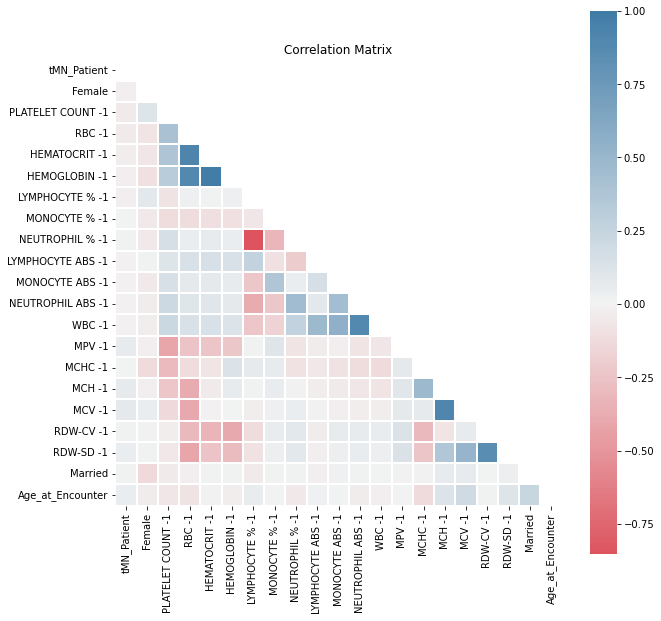

```python
# dd.correlation_matrix(dfN1_noMRN, cluster = True)
```

```python
# dfN1_noMRN.corr()["tMN_Patient"].sort_values(ascending=False)
```

```
tMN_Patient          1.000000
MCV -1               0.075232
MCH -1               0.067886
MPV -1               0.057469
Age_at_Encounter     0.042973
RDW-SD -1            0.042081
NEUTROPHIL % -1      0.014081
Married              0.013559
RDW-CV -1            0.010632
MCHC -1              0.005398
MONOCYTE % -1        0.003502
NEUTROPHIL ABS -1   -0.006886
LYMPHOCYTE ABS -1   -0.010224
MONOCYTE ABS -1     -0.011115
WBC -1              -0.011775
Female              -0.014026
LYMPHOCYTE % -1     -0.014747
HEMOGLOBIN -1       -0.020647
HEMATOCRIT -1       -0.022401
PLATELET COUNT -1   -0.041275
RBC -1              -0.047014
Name: tMN_Patient, dtype: float64
```

```python
# RUN

# import data_describe as dd

# dd.importance(dfN1_noMRN, 'tMN_Patient')
```

[output not shown]

[output cut: 71 more lines]

[output not shown]

```python
# import dask.dataframe as dd
# from data_describe.core.importance import _get_compute_backend

# # Assuming dfN1_noMRN is a Dask DataFrame
# ddf = dd.from_pandas(dfN1_noMRN, npartitions=10)  # Adjust the number of partitions as needed

# # Compute variable importance using Dask
# importance_values, idx, cols = _get_compute_backend('dask', ddf).compute_importance(ddf, 'tMN_Patient')
```

[output not shown]

```python
# Run

# import dask.dataframe as dd
# from sklearn.ensemble import RandomForestClassifier
# from sklearn.model_selection import train_test_split

# # Assuming dfN1_noMRN is a Dask DataFrame
# ddf = dd.from_pandas(dfN1_noMRN, npartitions=10)

# # Split the data into features and target
# X = ddf.drop(columns=['tMN_Patient'])
# y = ddf['tMN_Patient']

# # Split the data into training and testing sets
# X_train, X_test, y_train, y_test = train_test_split(X.compute(), y.compute(), test_size=0.2, random_state=42)

# # Initialize RandomForestClassifier
# rf = RandomForestClassifier()

# # Fit the model
# rf.fit(X_train, y_train)

# # Compute variable importance
# importance_values = rf.feature_importances_
# features = X_train.columns

# # Print or use the importance values as needed
# print(dict(zip(features, importance_values)))
```

[output not shown]

[output cut: 86 more lines]

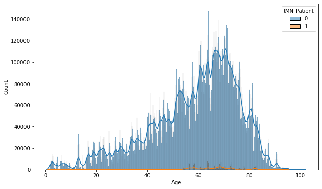

```python
# plt.figure(figsize=(10,6))
# sns.histplot(data = dfN1_noMRN, x = "Age_at_Encounter", kde = True, hue = "tMN_Patient")
# plt.xlabel('Age')
# plt.ylabel('Count')
```

```python
print(dfN1_noMRN.columns)
```

```
Index(['tMN_Patient', 'HEMATOCRIT -1', 'HEMOGLOBIN -1', 'LYMPHOCYTE % -1',
       'LYMPHOCYTE ABS -1', 'MCH -1', 'MCHC -1', 'MCV -1', 'MONOCYTE % -1',
       'MONOCYTE ABS -1', 'MPV -1', 'NEUTROPHIL % -1', 'NEUTROPHIL ABS -1',
       'PLATELET COUNT -1', 'RBC -1', 'RDW-CV -1', 'RDW-SD -1', 'WBC -1',
       'Married', 'Female', 'Age_at_Encounter'],
      dtype='object')
```

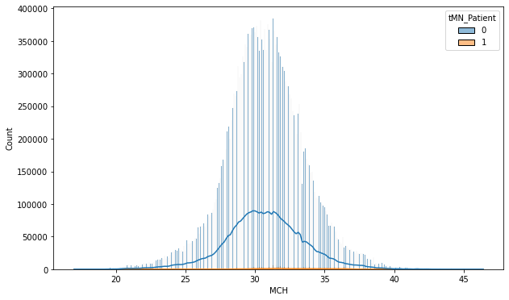

```python
# plt.figure(figsize=(10,6))
# sns.histplot(data = dfN1_noMRN, x = "MCH -1", kde = True, hue = "tMN_Patient")
# plt.xlabel('MCH')
# plt.ylabel('Count')
```

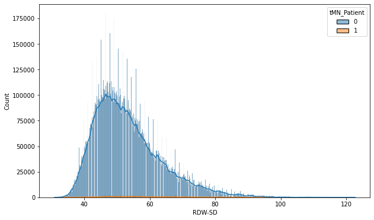

```python
# plt.figure(figsize=(10,6))
# sns.histplot(data = dfN1_noMRN, x = "RDW-SD -1", kde = True, hue = "tMN_Patient")
# plt.xlabel('RDW-SD')
# plt.ylabel('Count')
```

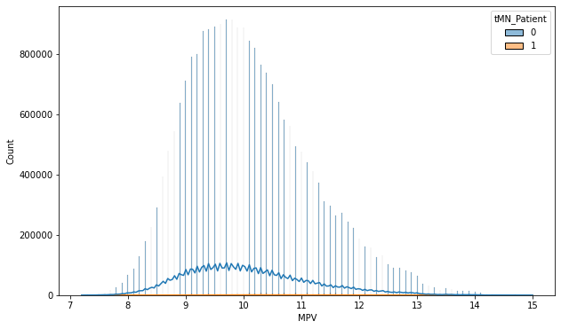

```python
# plt.figure(figsize=(10,6))
# sns.histplot(data = dfN1_noMRN, x = "MPV -1", kde = True, hue = "tMN_Patient")
# plt.xlabel('MPV')
# plt.ylabel('Count')
```

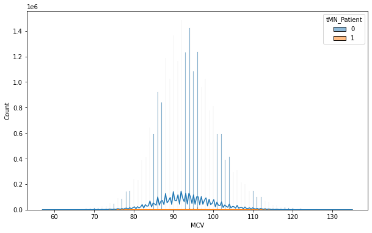

```python
# plt.figure(figsize=(10,6))
# sns.histplot(data = dfN1_noMRN, x = "MCV -1", kde = True, hue = "tMN_Patient")
# plt.xlabel('MCV')
# plt.ylabel('Count')
```

[figure not shown]

```python
# plt.figure(figsize=(10,6))
# sns.histplot(data = dfN1_noMRN, x = "MCV", kde = True, hue = "tMN_Patient")
# plt.xlabel('MCV')
# plt.ylabel('Count')
```

[output not shown]

[output cut: 42 more lines]

[output not shown]

[figure not shown]

```python
# import seaborn as sns
# import matplotlib.pyplot as plt

# # Assuming df is your DataFrame and 'MCV' is the column of interest
# sns.histplot(dfN1_noMRN['MCV -1'], kde=True, bins=30, bw_adjust=2)  # Adjust the bandwidth as needed
# plt.show()
```

[output not shown]

[output cut: 31 more lines]

[output not shown]

[figure not shown]

```python
# import seaborn as sns
# import matplotlib.pyplot as plt

# # Assuming df is your DataFrame and 'MCV' is the column of interest
# sns.histplot(dfN1_noMRN['MCV -1'], kde=True, bins=30)
# sns.kdeplot(dfN1_noMRN['MCV -1'], bw_adjust=2)  # Adjust the bandwidth as needed
# plt.show()
```

```python
# g = sns.PairGrid(dfN1_noMRN, x_vars=['Female'], y_vars=['tMN_Patient'])
# g.map(sns.pointplot)
```

```python
# g = sns.PairGrid(dfN1_noMRN, x_vars=['Married'], y_vars=['tMN_Patient'])
# g.map(sns.pointplot)
```

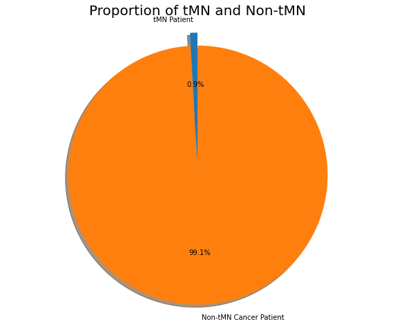

```python
labels = 'tMN Patient', 'Non-tMN Cancer Patient'

sizes = [dfN1_noMRN.tMN_Patient[dfN1_noMRN["tMN_Patient"]==1].count(), dfN1_noMRN.tMN_Patient[dfN1_noMRN["tMN_Patient"]==0].count()]

explode = (0, 0.1)

fig1, ax1 = plt.subplots(figsize=(10, 8))

ax1.pie(sizes, explode=explode, labels=labels, autopct='%1.1f%%',
        shadow=True, startangle=90)

ax1.axis('equal')

plt.title("Proportion of tMN and Non-tMN", size = 20)

plt.show()
```

[output not shown]

[output cut: 37 more lines]

[output not shown]

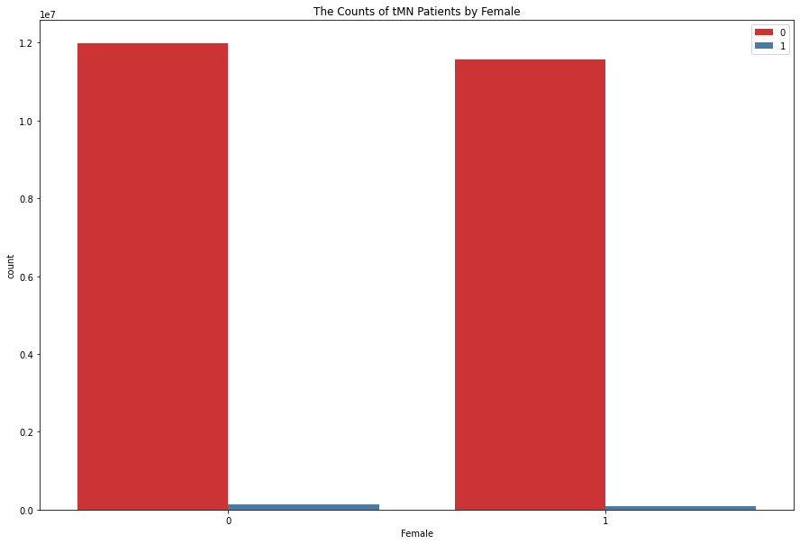

```python
# plt.figure(figsize=(15,10))
# sns.countplot(x="Female",hue="tMN_Patient", data=dfN1_noMRN, palette="Set1")

# plt.title("The Counts of tMN Patients by Female")
# plt.legend()

# print("Percentage Male Heart disease in Dataset: ",dfN1_noMRN[(dfN1_noMRN['tMN_Patient']==1) & (dfN1_noMRN['Female']==0)]['Female'].count()/dfN1_noMRN[dfN1_noMRN['Female']==1]['Female'].count())
# print("Percentage Female Heart disease in Dataset: ",dfN1_noMRN[(dfN1_noMRN['tMN_Patient']==1) & (dfN1_noMRN['Female']==1)]['Female'].count()/dfN1_noMRN[dfN1_noMRN['Female']==0]['Female'].count())
```

## Data Cleaning

```python
dfN1_noMRN.count()
```

```
tMN_Patient          23759965
HEMATOCRIT -1        23759965
HEMOGLOBIN -1        23759965
LYMPHOCYTE % -1      23759965
LYMPHOCYTE ABS -1    23759965
MCH -1               23759965
MCHC -1              23759965
MCV -1               23759965
MONOCYTE % -1        23759965
MONOCYTE ABS -1      23759965
MPV -1               23759965
NEUTROPHIL % -1      23759965
NEUTROPHIL ABS -1    23759965
PLATELET COUNT -1    23759965
RBC -1               23759965
RDW-CV -1            23759965
RDW-SD -1            23759965
WBC -1               23759965
Married              23759965
Female               23759965
Age_at_Encounter     23759965
dtype: int64
```

## 4) Feature Engineering

### Normalization

Normalize the features for better processing

```python
dfN1_scale = dfN1_noMRN.copy()
```

```python
from sklearn.preprocessing import StandardScaler
from sklearn.model_selection import train_test_split
from sklearn.ensemble import RandomForestClassifier
from sklearn.metrics import classification_report
```

```python
# Index(['tMN_Patient', 'HEMATOCRIT -1', 'HEMOGLOBIN -1', 'LYMPHOCYTE % -1',
#        'LYMPHOCYTE ABS -1', 'MCH -1', 'MCHC -1', 'MCV -1', 'MONOCYTE % -1',
#        'MONOCYTE ABS -1', 'MPV -1', 'NEUTROPHIL % -1', 'NEUTROPHIL ABS -1',
#        'PLATELET COUNT -1', 'RBC -1', 'RDW-CV -1', 'RDW-SD -1', 'WBC -1',
#        'Married', 'Female', 'Age_at_Encounter'],
```

```python
ss = StandardScaler()
dfN1_scale[['HEMATOCRIT -1', 'HEMOGLOBIN -1', 'LYMPHOCYTE % -1', 'LYMPHOCYTE ABS -1','MCH -1', 'MCHC -1', 'MCV -1', 'MONOCYTE % -1',
            'MONOCYTE ABS -1', 'MPV -1', 'NEUTROPHIL % -1', 'NEUTROPHIL ABS -1', 'PLATELET COUNT -1', 'RBC -1', 'RDW-CV -1', 'RDW-SD -1', 'WBC -1',
            'Age_at_Encounter']] = ss.fit_transform(dfN1_noMRN[['HEMATOCRIT -1', 'HEMOGLOBIN -1', 'LYMPHOCYTE % -1', 'LYMPHOCYTE ABS -1','MCH -1', 'MCHC -1', 'MCV -1', 'MONOCYTE % -1',
            'MONOCYTE ABS -1', 'MPV -1', 'NEUTROPHIL % -1', 'NEUTROPHIL ABS -1', 'PLATELET COUNT -1', 'RBC -1', 'RDW-CV -1', 'RDW-SD -1', 'WBC -1',
            'Age_at_Encounter']])
```

```python
dfN1_scale
```

|  | tMN_Patient | HEMATOCRIT -1 | HEMOGLOBIN -1 | LYMPHOCYTE % -1 | LYMPHOCYTE ABS -1 | MCH -1 | MCHC -1 | MCV -1 | MONOCYTE % -1 | MONOCYTE ABS -1 | MPV -1 | NEUTROPHIL % -1 | NEUTROPHIL ABS -1 | PLATELET COUNT -1 | RBC -1 | RDW-CV -1 | RDW-SD -1 | WBC -1 | Married | Female | Age_at_Encounter |
| --- | --- | --- | --- | --- | --- | --- | --- | --- | --- | --- | --- | --- | --- | --- | --- | --- | --- | --- | --- | --- | --- |
| 0 | 0 | 0.205384 | 0.212370 | -0.659191 | -0.301006 | -0.294310 | -0.001679 | -0.312388 | -0.041121 | -0.273862 | -0.736232 | 0.585739 | -0.237296 | 0.215182 | 0.298946 | -0.359616 | -0.478345 | -0.352262 | 0 | 1 | 0.763598 |
| 1 | 0 | 0.205384 | 0.212370 | -0.659191 | -0.301006 | -0.294310 | -0.001679 | -0.312388 | -0.041121 | -0.273862 | -0.736232 | 0.585739 | -0.237296 | 0.215182 | 0.298946 | -0.359616 | -0.478345 | -0.352262 | 0 | 1 | 0.763598 |
| 2 | 0 | 0.205384 | 0.212370 | -0.659191 | -0.301006 | -0.294310 | -0.001679 | -0.312388 | -0.041121 | -0.273862 | -0.736232 | 0.585739 | -0.237296 | 0.215182 | 0.298946 | -0.359616 | -0.478345 | -0.352262 | 0 | 1 | 0.763598 |
| 3 | 0 | 0.205384 | 0.212370 | -0.659191 | -0.301006 | -0.294310 | -0.001679 | -0.312388 | -0.041121 | -0.273862 | -0.736232 | 0.585739 | -0.237296 | 0.215182 | 0.298946 | -0.359616 | -0.478345 | -0.352262 | 0 | 1 | 0.763598 |
| 4 | 0 | 0.205384 | 0.212370 | -0.659191 | -0.301006 | -0.294310 | -0.001679 | -0.312388 | -0.041121 | -0.273862 | -0.736232 | 0.585739 | -0.237296 | 0.215182 | 0.298946 | -0.359616 | -0.478345 | -0.352262 | 0 | 1 | 0.763598 |
| ... | ... | ... | ... | ... | ... | ... | ... | ... | ... | ... | ... | ... | ... | ... | ... | ... | ... | ... | ... | ... | ... |
| 23759960 | 0 | -0.825472 | -0.850029 | -0.226671 | -0.466080 | -1.382288 | -0.232995 | -1.484919 | 2.528034 | -0.627422 | 2.381321 | -1.574280 | -0.800761 | -0.857387 | -0.230200 | -0.650375 | -1.118249 | -0.891810 | 1 | 1 | 0.690916 |
| 23759961 | 0 | -0.825472 | -0.850029 | -0.226671 | -0.466080 | -1.382288 | -0.232995 | -1.484919 | 2.528034 | -0.627422 | 2.381321 | -1.574280 | -0.800761 | -0.857387 | -0.230200 | -0.650375 | -1.118249 | -0.891810 | 1 | 1 | 0.690916 |
| 23759962 | 0 | -0.825472 | -0.850029 | -0.226671 | -0.466080 | -1.382288 | -0.232995 | -1.484919 | 2.528034 | -0.627422 | 2.381321 | -1.574280 | -0.800761 | -0.857387 | -0.230200 | -0.650375 | -1.118249 | -0.891810 | 1 | 1 | 0.690916 |
| 23759963 | 0 | -0.825472 | -0.850029 | -0.226671 | -0.466080 | -1.382288 | -0.232995 | -1.484919 | 2.528034 | -0.627422 | 2.381321 | -1.574280 | -0.800761 | -0.857387 | -0.230200 | -0.650375 | -1.118249 | -0.891810 | 1 | 1 | 0.690916 |
| 23759964 | 0 | -0.825472 | -0.850029 | -0.226671 | -0.466080 | -1.382288 | -0.232995 | -1.484919 | 2.528034 | -0.627422 | 2.381321 | -1.574280 | -0.800761 | -0.857387 | -0.230200 | -0.650375 | -1.118249 | -0.891810 | 1 | 1 | 0.690916 |

23759965 rows × 21 columns

## Downsizing - Undersampling

- we perform undersampling after scaling

Scaling:

Scaling is often applied first to ensure that all features are on a similar scale. Many machine learning models, especially distance-based models like Support Vector Machines (SVM) or k-Nearest Neighbors (k-NN), can be sensitive to the scale of features. Common scaling techniques include Standard Scaling (Z-score normalization) or Min-Max Scaling.

Undersampling:

Undersampling is typically applied after scaling, especially if you are using techniques like Random Undersampling or NearMiss. The reason is that undersampling before scaling might lead to information loss, as you might discard samples from the minority class before representing them on a common scale.

### 1. Random Undersampling:

```python
from imblearn.under_sampling import RandomUnderSampler
from sklearn.datasets import make_classification
import matplotlib.pyplot as plt
import seaborn as sns
```

```python
X = dfN1_scale.drop(['tMN_Patient'], axis=1)
y = dfN1_scale['tMN_Patient']
```

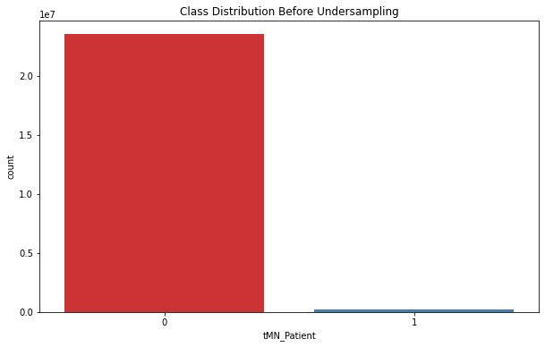

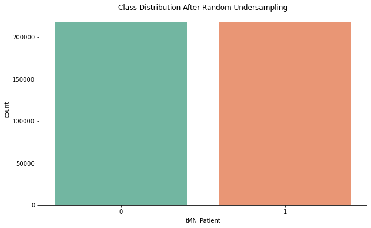

```python
# Apply Random Undersampling
rus = RandomUnderSampler(sampling_strategy='auto', random_state=42)
X_resampled, y_resampled = rus.fit_resample(X, y)

# Visualize the class distribution before and after undersampling
plt.figure(figsize=(10, 6))
sns.countplot(y, palette='Set1')
plt.title("Class Distribution Before Undersampling")

plt.figure(figsize=(10, 6))
sns.countplot(y_resampled, palette='Set2')
plt.title("Class Distribution After Random Undersampling")
```

```python
X_resampled
```

|  | HEMATOCRIT -1 | HEMOGLOBIN -1 | LYMPHOCYTE % -1 | LYMPHOCYTE ABS -1 | MCH -1 | MCHC -1 | MCV -1 | MONOCYTE % -1 | MONOCYTE ABS -1 | MPV -1 | NEUTROPHIL % -1 | NEUTROPHIL ABS -1 | PLATELET COUNT -1 | RBC -1 | RDW-CV -1 | RDW-SD -1 | WBC -1 | Married | Female | Age_at_Encounter |
| --- | --- | --- | --- | --- | --- | --- | --- | --- | --- | --- | --- | --- | --- | --- | --- | --- | --- | --- | --- | --- |
| 13255605 | -0.229508 | -0.125666 | -0.477407 | -0.315155 | 1.320108 | 0.460954 | 1.250986 | -0.947882 | -0.711602 | -0.186076 | 0.782105 | -0.351386 | -0.848374 | -0.664371 | 1.821083 | 2.032792 | -0.496141 | 1 | 0 | 0.290936 |
| 8846024 | 0.430884 | 0.791860 | 1.647581 | 1.005436 | 2.267702 | 1.617536 | 1.641830 | -0.479389 | -0.071829 | 0.730852 | -1.159108 | -0.253594 | -0.929493 | -0.270903 | -1.159205 | -0.381390 | 0.151316 | 0 | 0 | -2.130513 |
| 17755524 | -1.083186 | -1.139774 | -0.477407 | -0.131216 | 0.688379 | -0.464312 | 0.990424 | 0.714513 | 0.466928 | -1.103003 | 0.164956 | -0.074310 | 1.648279 | -1.302059 | -0.214236 | 0.035517 | -0.064503 | 1 | 0 | 0.199055 |
| 23532477 | -2.097936 | -1.912427 | 1.290282 | -0.121783 | -0.422996 | 1.283412 | -0.855227 | 0.140231 | -0.560077 | 0.455773 | -1.119834 | -0.668044 | -1.058682 | -1.563724 | 1.406750 | 0.680615 | -0.738246 | 1 | 0 | 0.184649 |
| 4761552 | 0.205384 | -0.125666 | -0.320697 | 0.048007 | -1.943825 | -1.543788 | -1.484919 | 0.351808 | 0.551109 | -0.736232 | 0.439868 | 0.198109 | 0.287288 | 0.882363 | -0.468651 | -1.069771 | 0.169301 | 1 | 1 | 0.586513 |
| ... | ... | ... | ... | ... | ... | ... | ... | ... | ... | ... | ... | ... | ... | ... | ... | ... | ... | ... | ... | ... |
| 12071850 | 0.189277 | 0.212370 | 0.525537 | -0.197245 | -0.259214 | 0.075426 | -0.312388 | -0.267812 | -0.610585 | 0.180695 | -1.024457 | -0.635447 | -0.325609 | 0.285378 | 0.003834 | -0.206871 | -0.622036 | 1 | 0 | 0.130830 |
| 12071851 | 0.189277 | 0.212370 | 0.525537 | -0.197245 | -0.259214 | 0.075426 | -0.312388 | -0.267812 | -0.610585 | 0.180695 | -1.024457 | -0.635447 | -0.325609 | 0.285378 | 0.003834 | -0.206871 | -0.622036 | 1 | 0 | 0.145286 |
| 12071852 | 0.189277 | 0.212370 | 0.525537 | -0.197245 | -0.259214 | 0.075426 | -0.312388 | -0.267812 | -0.610585 | 0.180695 | -1.024457 | -0.635447 | -0.325609 | 0.285378 | 0.003834 | -0.206871 | -0.622036 | 1 | 0 | 0.145286 |
| 12071853 | 0.189277 | 0.212370 | 0.525537 | -0.197245 | -0.259214 | 0.075426 | -0.312388 | -0.267812 | -0.610585 | 0.180695 | -1.024457 | -0.635447 | -0.325609 | 0.285378 | 0.003834 | -0.206871 | -0.622036 | 1 | 0 | 0.145286 |
| 12071854 | 0.189277 | 0.212370 | 0.525537 | -0.197245 | -0.259214 | 0.075426 | -0.312388 | -0.267812 | -0.610585 | 0.180695 | -1.024457 | -0.635447 | -0.325609 | 0.285378 | 0.003834 | -0.206871 | -0.622036 | 1 | 0 | 0.145286 |

434116 rows × 20 columns

```python
y_resampled.value_counts()
```

```
0    217058
1    217058
Name: tMN_Patient, dtype: int64
```